Welcome to the Artifact coding challenge ! We hope you'll have fun and wish you best of luck 😀

# Albert and the ear shells

[figure not shown]

Ear shells are marine snails

The age of ear shells can be determined by cutting the shell through the cone, staining it, and counting the number of rings through a microscope - a boring and time-consuming task.

**Albert**, a scientist and **ear shells** specialist, needs your help. He has collected data on his favorite sea creature and asks you to help him understand it. He is looking for your help to develop a model to predict the number of rings of ear shells (a proxy to their age) using other measurements which are easier to obtain.

# Part 0: Setup

Please include any setup code (including imports) in this section

```python
import pandas as pd
import numpy as np
import matplotlib.pyplot as plt
import seaborn as sns
from sklearn.ensemble import RandomForestRegressor, GradientBoostingRegressor
from sklearn.linear_model import LinearRegression
from sklearn.metrics import mean_absolute_error, mean_squared_error, r2_score
from sklearn.preprocessing import LabelEncoder
```

# Part 1: Data understanding

## Questions

Albert needs your help getting a deeper understanding of one particular aspect of this data: the price of ear shells. Can you help him?

### Question 1.1

Albert needs your help getting a deeper understanding of one particular aspect of this data: the price of ear shells. Can you help him?

```python
df = pd.read_csv('earshells.csv')
print("Shape:", df.shape)
print("\nData types:")
print(df.dtypes)
print("\nMissing values:")
print(df.isnull().sum())
print("\nBasic statistics:")
df.describe()
```

```
Shape: (3177, 11)

Data types:
subset             object
sex                object
length            float64
diameter          float64
height            float64
weight_whole      float64
weight_shucked    float64
weight_viscera    float64
weight_shell      float64
rings             float64
price             float64
dtype: object

Missing values:
subset             0
sex                0
length             0
diameter           0
height             0
weight_whole       0
weight_shucked     0
weight_viscera     0
weight_shell       0
rings             31
price             31
dtype: int64

Basic statistics:
```

|  | length | diameter | height | weight_whole | weight_shucked | weight_viscera | weight_shell | rings | price |
| --- | --- | --- | --- | --- | --- | --- | --- | --- | --- |
| count | 3177.000000 | 3177.000000 | 3177.000000 | 3177.000000 | 3177.000000 | 3177.000000 | 3177.000000 | 3146.000000 | 3146.000000 |
| mean | 0.514375 | 0.400714 | 0.137637 | 0.762373 | 0.342208 | 0.171391 | 0.214673 | 8.688175 | 12.009143 |
| std | 0.134573 | 0.127037 | 0.085215 | 0.466921 | 0.221293 | 0.136696 | 0.134109 | 1.651814 | 8.960992 |
| min | 0.000000 | 0.000000 | 0.000000 | 0.000000 | 0.000000 | 0.000000 | 0.000000 | 5.000000 | 0.100000 |
| 25% | 0.430460 | 0.330106 | 0.105429 | 0.380575 | 0.164394 | 0.081092 | 0.111925 | 8.000000 | 4.411906 |
| 50% | 0.525344 | 0.409005 | 0.135146 | 0.708931 | 0.311135 | 0.152980 | 0.200168 | 9.000000 | 9.997860 |
| 75% | 0.604511 | 0.474416 | 0.159903 | 1.084999 | 0.489803 | 0.238231 | 0.296527 | 10.000000 | 18.254280 |
| max | 1.973813 | 3.491197 | 2.662290 | 2.987259 | 1.905003 | 3.196680 | 1.545075 | 11.000000 | 52.901790 |

```python
df.head(10)
```

|  | subset | sex | length | diameter | height | weight_whole | weight_shucked | weight_viscera | weight_shell | rings | price |
| --- | --- | --- | --- | --- | --- | --- | --- | --- | --- | --- | --- |
| 0 | train | I | 0.349544 | 0.260194 | 0.074504 | 0.179963 | 0.089707 | 0.024760 | 0.054516 | 5.0 | 1.205721 |
| 1 | train | F | 0.545249 | 0.439866 | 0.134915 | 0.918132 | 0.428983 | 0.201751 | 0.237840 | 10.0 | 18.403463 |
| 2 | test | F | 0.649654 | 0.544545 | 0.175080 | 1.524459 | 0.590134 | 0.325970 | 0.495506 | 10.0 | 31.455767 |
| 3 | train | I | 0.500003 | 0.394566 | 0.140912 | 0.621133 | 0.292336 | 0.120165 | 0.195429 | 9.0 | 5.647747 |
| 4 | train | I | 0.439268 | 0.335001 | 0.110040 | 0.389429 | 0.175157 | 0.083279 | 0.110899 | 7.0 | 1.966989 |
| 5 | train | I | 0.294596 | 0.220013 | 0.084899 | 0.129350 | 0.058167 | 0.027437 | 0.036809 | 5.0 | 0.229251 |
| 6 | train | I | 0.475259 | 0.364612 | 0.120313 | 0.518502 | 0.268031 | 0.109303 | 0.136601 | 8.0 | 4.142997 |
| 7 | train | M | 0.549885 | 0.451143 | 0.149154 | 1.014219 | 0.407824 | 0.201920 | 0.287036 | 10.0 | 16.212238 |
| 8 | train | I | 0.464834 | 0.355262 | 0.119326 | 0.580638 | 0.254973 | 0.091545 | 0.183995 | 8.0 | 7.455883 |
| 9 | test | I | 0.379859 | 0.290154 | 0.100127 | 0.236797 | 0.107936 | 0.039838 | 0.082200 | 6.0 | 2.284661 |

### Question 1.2

What's the **average price** for ear shells with a **diameter** falling outside the interquartile range (of diameter) ?

```python
Q1 = df['diameter'].quantile(0.25)
Q3 = df['diameter'].quantile(0.75)

outside_iqr = df[(df['diameter'] < Q1) | (df['diameter'] > Q3)]

avg_price = outside_iqr['price'].mean()
print(f"Q1: {Q1:.4f}, Q3: {Q3:.4f}")
print(f"Number of ear shells outside IQR: {len(outside_iqr)}")
print(f"Average price for ear shells with diameter outside IQR: {avg_price:.2f}")
```

```
Q1: 0.3301, Q3: 0.4744
Number of ear shells outside IQR: 1588
Average price for ear shells with diameter outside IQR: 13.12
```

### Question 1.3

Albert would like to understand which factors / attributes have been used to determine the price. Please provide him with **one clear visualization** which explicits the dependency between the price and the most relevant attributes. Provide an interpretation and some insights on the visualization.

```python
# Correlation with price
numeric_cols = df.select_dtypes(include=[np.number]).columns
correlations = df[numeric_cols].corr()['price'].drop('price').sort_values(ascending=False)
print("Correlations with price:")
print(correlations)
```

```
Correlations with price:
weight_whole      0.944401
weight_viscera    0.924135
weight_shucked    0.921571
weight_shell      0.913183
diameter          0.864304
length            0.862894
height            0.751960
rings             0.608401
Name: price, dtype: float64
```

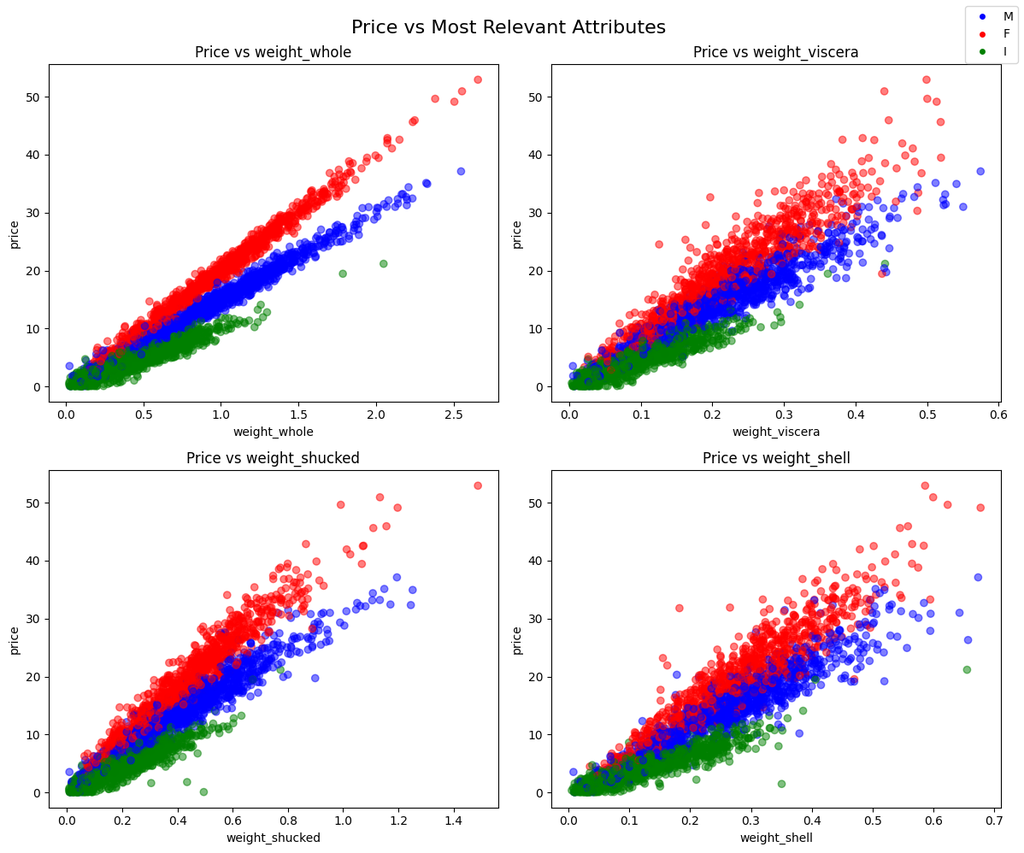

```python
# Select top correlated features
top_features = correlations.abs().sort_values(ascending=False).head(4).index.tolist()

fig, axes = plt.subplots(2, 2, figsize=(12, 10))
fig.suptitle('Price vs Most Relevant Attributes', fontsize=16)

for i, feat in enumerate(top_features):
    ax = axes[i // 2][i % 2]
    ax.scatter(df[feat], df['price'], alpha=0.5, c=df['sex'].map({'M': 'blue', 'F': 'red', 'I': 'green'}))
    ax.set_xlabel(feat)
    ax.set_ylabel('price')
    ax.set_title(f'Price vs {feat}')

# Add legend
from matplotlib.lines import Line2D
legend_elements = [Line2D([0], [0], marker='o', color='w', markerfacecolor='blue', label='M'),
                   Line2D([0], [0], marker='o', color='w', markerfacecolor='red', label='F'),
                   Line2D([0], [0], marker='o', color='w', markerfacecolor='green', label='I')]
fig.legend(handles=legend_elements, loc='upper right')

plt.tight_layout()
plt.savefig('visualization.png', dpi=150, bbox_inches='tight')
plt.show()
```

What I see here is that the four weight-related features show the strongest correlation with price. All exhibit a clear positive linear relationship — heavier ear shells are more expensive. Females (red) consistently command higher prices than males (blue) for similar weights, while infants (green) cluster at the lower end. weight_whole appears to be the single best predictor of price. This suggests price is primarily driven by size/weight, with sex playing a secondary role (likely because females tend to grow larger).

# Part 2: Modeling

Albert is a biologist who has read about ML in the newspapers. He asks you to use your ML skills to train a model that will predict the **number of rings** based on the other attributes.

Albert was kind enough to pre-assign the dataset samples to train-test with the `subset` attribute.

### Question 2.1

Which model will you choose to accomplish this task? Propose two different approaches to Albert and explain to him the tradeoff between the two options to help him choose between the two. Which of the two approaches would you choose? Explain your choice.

1: Linear Regression — Simple, interpretable, fast to train. Albert can easily understand which features matter and by how much (coefficients). However, it assumes a linear relationship and may underfit if the true relationship is more complex.

2: Random Forest Regressor — Captures non-linear relationships and feature interactions automatically. More robust to outliers and doesn't require feature scaling. However, it's a "black box" and harder to interpret.

My choice: Random Forest — While interpretability is valuable for Albert, accurately predicting ring count is the primary goal. Random Forest typically outperforms linear models on tabular data with potential non-linear patterns, and we can still use feature importances to provide some interpretability.

### Question 2.2

Implement and evaluate the approach you chose. Which metric did you choose to communicate the performance of your model to Albert ? Justify your choice.

```python
# Prepare data using the pre-assigned train/test split
train = df[df['subset'] == 'train'].copy()
test = df[df['subset'] == 'test'].copy()

# Encode 'sex' column
le = LabelEncoder()
train['sex_encoded'] = le.fit_transform(train['sex'])
test['sex_encoded'] = le.transform(test['sex'])

# Features (exclude subset, sex, rings, price)
features = ['sex_encoded', 'length', 'diameter', 'height',
            'weight_whole', 'weight_shucked', 'weight_viscera', 'weight_shell']

# Drop rows with NaN in rings
train = train.dropna(subset=['rings'])
test = test.dropna(subset=['rings'])

X_train = train[features]
y_train = train['rings']
X_test = test[features]
y_test = test['rings']

print(f"Train size: {X_train.shape[0]}, Test size: {X_test.shape[0]}")
```

```
Train size: 2831, Test size: 315
```

```python
# Train Random Forest
rf = RandomForestRegressor(n_estimators=200, random_state=42)
rf.fit(X_train, y_train)

# Predictions
y_pred = rf.predict(X_test)

# Evaluation
mae = mean_absolute_error(y_test, y_pred)
rmse = np.sqrt(mean_squared_error(y_test, y_pred))
r2 = r2_score(y_test, y_pred)

print(f"MAE:  {mae:.3f}")
print(f"RMSE: {rmse:.3f}")
print(f"R²:   {r2:.3f}")
```

```
MAE:  0.886
RMSE: 1.105
R²:   0.550
```

### Question 2.3

How's your model performing? Interpret the performances of your model. Feel free to justify your statement with additional code or visualization.

Discuss the limitations and potential improvements of your model (additional code is not required here).

```
Feature importances:
weight_shell      0.586514
weight_shucked    0.074547
diameter          0.071023
height            0.061738
weight_viscera    0.061326
length            0.059632
weight_whole      0.046326
sex_encoded       0.038894
dtype: float64
```

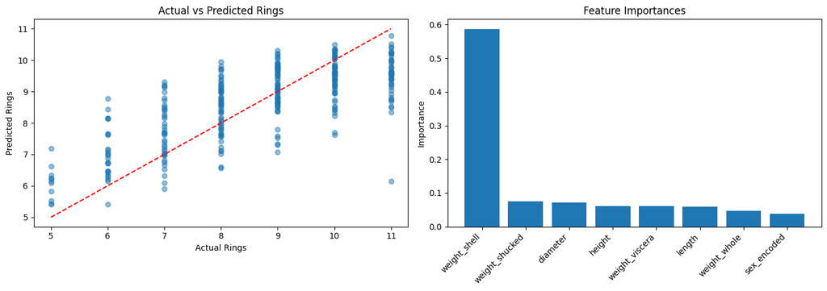

```python
# Feature importances
importances = pd.Series(rf.feature_importances_, index=features).sort_values(ascending=False)
print("Feature importances:")
print(importances)

# Actual vs Predicted plot
fig, axes = plt.subplots(1, 2, figsize=(14, 5))

axes[0].scatter(y_test, y_pred, alpha=0.5)
axes[0].plot([y_test.min(), y_test.max()], [y_test.min(), y_test.max()], 'r--')
axes[0].set_xlabel('Actual Rings')
axes[0].set_ylabel('Predicted Rings')
axes[0].set_title('Actual vs Predicted Rings')

axes[1].bar(importances.index, importances.values)
axes[1].set_xticklabels(importances.index, rotation=45, ha='right')
axes[1].set_title('Feature Importances')
axes[1].set_ylabel('Importance')

plt.tight_layout()
plt.show()
```

Performance Interpretation:

MAE of 0.886 means on average our prediction is off by less than 1 ring, which is reasonable given that ring count is an integer. R² of 0.55 means the model explains about 55% of the variance in ring count — decent but with room for improvement. The Actual vs Predicted plot shows the model performs well for mid-range values but struggles with extreme values (very young or very old shells). Limitations:

The model only explains ~55% of the variance, suggesting important predictive information may be missing from the dataset. Random Forest can overfit on small datasets — cross-validation would give a more robust estimate. The sex encoding (LabelEncoder) introduces an artificial ordinal relationship between categories. One-hot encoding would be more appropriate. Potential improvements:

Maybe useing XGBoost as well and compare the result Use one-hot encoding for the sex feature instead of label encoding. Hyperparameter tuning (max_depth, min_samples_split) via grid search or cross-validation. Feature engineering: create interaction features (e.g., weight ratios, volume estimates).

# The end !

Thank you for participating in this challenge, we hope you enjoyed it !

Don't forget to submit your work by email and to **include a zip of your work** containing:

- your notebook `challenge.ipynb`
- an export of your notebook as HTML `challenge.html`
- a `requirements.txt` file listing your dependencies
- an image of your visualization for question 1.2